# Project 2 phase 3

Katarzyna Kańska, Annanina Koster, Emilia Pompe

January 7, 2016

# Introduction

This project focuses on explaining what factors influence the length of dendritic spine, whose condition is believed to affect occurrence of several cognitive disorders.

We use the dataset `dendriticSpines.rda`, which contains `38182` observations of lengths of mice’s dendritic spines. This data was collected during `3` studies and includes `3` different mouse types and `5` different types of treatment.

The available variables in this dataset are

```
## [1] "Animal"       "Photo_ID_abs" "spine_number" "length"
## [5] "Study"        "mouse"        "treatment"
```

Treatments are:

```
##      - chiron   dmso     gm     li
##   2916   6158  15718   9794   3596
```

The mouse ,,types’’ are:

```
##    KO    TG    WT
##  3066 16159 18957
```

which stands for

- WT (wild type) normal mice,
- TG (transgenic) mice with additional genetic material,
- KO (knock out) mice with a removed gene.

The way how spines are measured is following: from mouse ‘Animal ID’ the part (slice) of the brain is extracted. The slice is threated with treatment and then photos of slices are taken. `Photo_ID_abs` is the ID of the photo, note that this factor is nested in the Animal ID. In each photo different spines are visible. Length of spines visible on each photo is measured.

# The research objective

The research objective is to find out which treatments affect lengths of spines for different mice.

# Results

The model that we chose to be the final is the one presented below:

In the two previous phases the interaction between the method of treatment and the type of mouse was at the border of significance, eventually we decided to exclude it from the model. The reasoning together with statistical tests for it are shown in the appendix.

## Random effects

| Variable name | Effect (Std.Dev.) |
| --- | --- |
| `Study:Animal:mouse:Photo_ID_abs` | 0.1045 |
| `Study:Animal:mouse` | 0.0695 |

## Fixed effects

| Variable name | Effect | P-value |
| --- | --- | --- |
| `(mouse)TG` | 0.13181 | 2.348908e-02 `*` |
| `(mouse)WT` | 0.11227 | 1.735257e-02 `*` |
| `(treatment)chiron` | 0.46508 | 5.087255e-19 `***` |
| `(treatment)dmso` | 0.56048 | 5.685934e-29 `***` |
| `(treatment)gm` | 0.53317 | 3.682575e-25 `***` |
| `(treatment)li` | -0.16028 | 7.800295e-04 `**` |

Signif. codes: 0 `***` 0.001 `**` 0.01 `*` 0.05 `.`

## Confidence intervals

Let us take a look at the most significant part of the results, which is the part concerning fixed effects is the model

```
##                       2.5 %   estimate      97.5 %      p.value
## mouseTG          0.02328657  0.1318059  0.24012755 2.348908e-02
## mouseWT          0.02387519  0.1122690  0.20025290 1.735257e-02
## treatmentchiron  0.36721357  0.4650821  0.56240947 5.087255e-19
## treatmentdmso    0.46711379  0.5604799  0.65450956 5.685934e-29
## treatmentgm      0.43761380  0.5331700  0.63056512 3.682575e-25
## treatmentli     -0.24925745 -0.1602750 -0.07096512 7.800295e-04
```

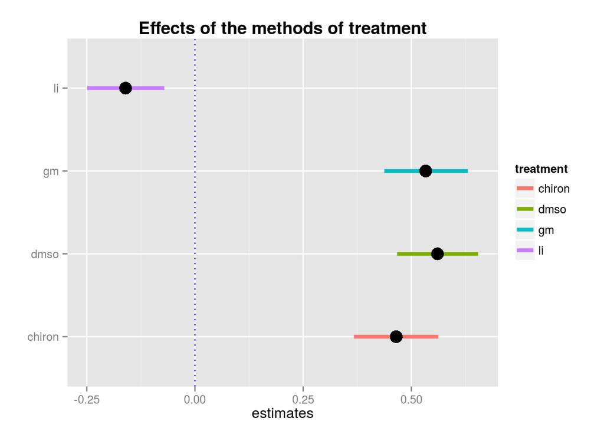

It turned out that all levels of treatment were significant:

- `chiron`, `dmso` and `gm` affect the length of dendritic spines positively,
- while `li` has negative impact.

The **`dmso`** treatment has the greatest impact.

# Appendix: Model validation

## Checking for significance of fixed effects (further)

Let us check whether interaction between the method of treatment and the type of mouse should be included model. To do this, we compared our final model with a slightly modified one (with interaction), calculating the p-value of the ANOVA test performed on the models:

```
## [1] 0.001367836
```

The p-value is equal to 0.001368, which indicates that the interaction term should be included. However, we used also BIC and AIC criteria to compare these models.

```
##                     AIC      BIC
## final.model    54784.72 54870.22
## model.version1 54787.76 54898.91
```

According to both BIC and AIC (in both cases smaller values were obtained for our final model), however, the interaction should be excluded from the model (including it could for example lead to overfitting). That is why in the last phase we decided to use a simpler model, without interaction.

## Significance of random effects

```
## Data: dendritic.data
## Models:
## model.version2: log(length) ~ mouse + treatment + (1 | Study:Animal:mouse:Photo_ID_abs)
## final.model: log(length) ~ mouse + treatment + (1 | Study:Animal:mouse) +
## final.model:     (1 | Study:Animal:mouse:Photo_ID_abs)
##                Df   AIC   BIC logLik deviance  Chisq Chi Df Pr(>Chisq)
## model.version2  9 54784 54861 -27383    54766
## final.model    10 54747 54832 -27363    54727 39.294      1  3.645e-10 ***
## ---
## Signif. codes:  0 '***' 0.001 '**' 0.01 '*' 0.05 '.' 0.1 ' ' 1
```

```
## Data: dendritic.data
## Models:
## model.version3: log(length) ~ mouse + treatment + (1 | Study:Animal:mouse)
## final.model: log(length) ~ mouse + treatment + (1 | Study:Animal:mouse) +
## final.model:     (1 | Study:Animal:mouse:Photo_ID_abs)
##                Df   AIC   BIC logLik deviance  Chisq Chi Df Pr(>Chisq)
## model.version3  9 55610 55687 -27796    55592
## final.model    10 54747 54832 -27363    54727 865.09      1  < 2.2e-16 ***
## ---
## Signif. codes:  0 '***' 0.001 '**' 0.01 '*' 0.05 '.' 0.1 ' ' 1
```

The results of ANOVA tests for random effects (small p-values in both cases) lead to a conclusion that both terms with random effects should be included in the final model. Let us check also the AIC and BIC criteria.

```
##                     AIC      BIC
## final.model    54784.72 54870.22
## model.version1 54827.27 54904.22
## model.version2 55650.68 55727.63
```

Both of them choose our model as the best one out of these three.

## Normality tests

Normality tests were performed to check whether the residuals are normally distributed (Jarque-Bera test) and whether random effects (coming from both terms) are normally distributed (Shapiro-Wilk tests). Let us take a look at the p-values:

```
## residuals    ranef1    ranef2
## 0.5812556 0.6667390 0.2502828
```

All of them are very high, hence normality assumptions are fulfilled in our model. Let us also examine the qqplot of model residuals.

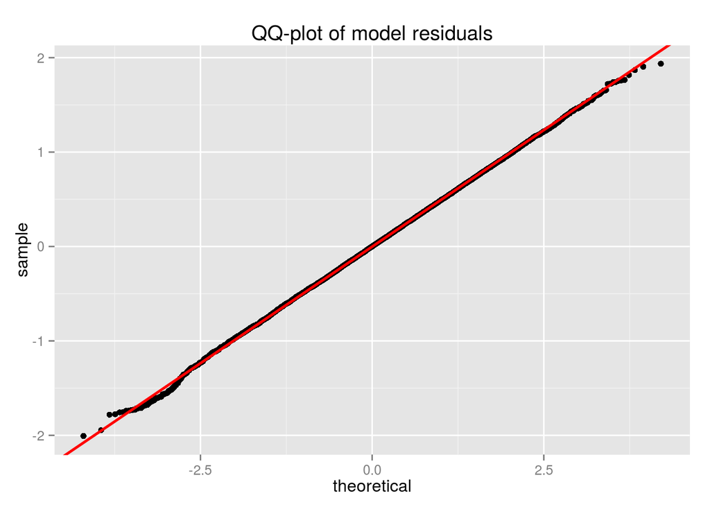

The fit to the Gaussian distribution is almost perfect. Besides, empirical cumulative function of random effects is close to the Gaussian c.d.f. (in both cases).

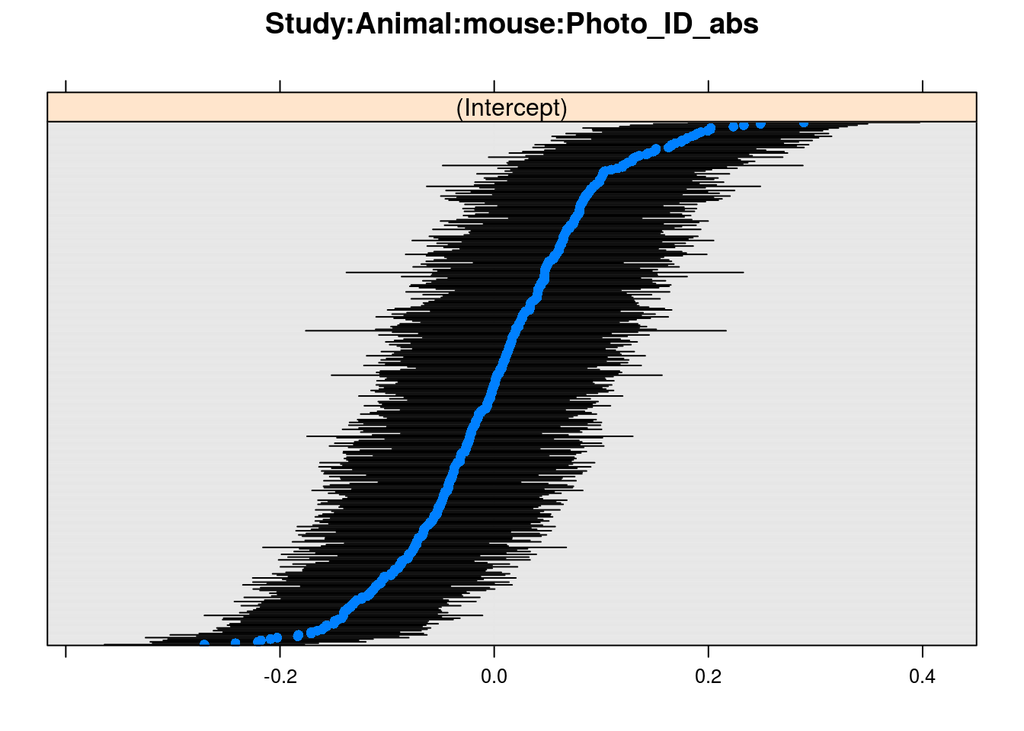

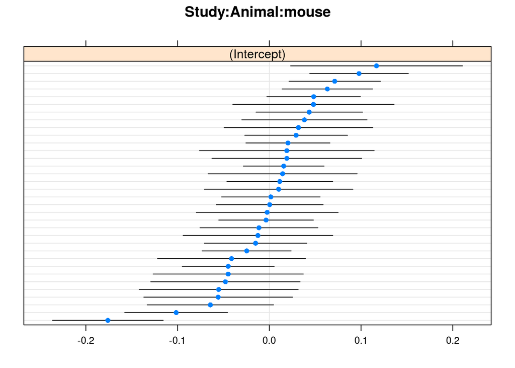

## Homogeneity of variance

```
##    mouse treatment       var
## 1     KO         - 0.1967958
## 2     KO        li 0.1909073
## 3     TG    chiron 0.2562485
## 4     TG      dmso 0.2655831
## 5     TG        gm 0.2399212
## 6     WT         - 0.2051514
## 7     WT    chiron 0.2527899
## 8     WT      dmso 0.2510786
## 9     WT        gm 0.2166617
## 10    WT        li 0.1930711
```

It can be observed, that the differences of variances between groups are small, which means that the assumption of homogeneity is satisfied.

## Independence of epsilons and random effects

Model residuals seem to be independent from random effects, which is presented in the charts below:

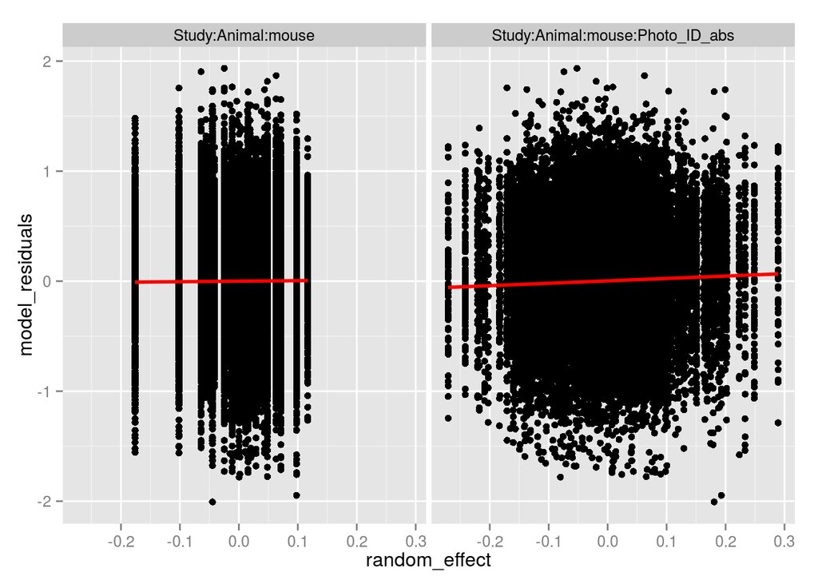